# TS

Kate

26 февраля 2019 г

# Данные: Ежемесячное количество осадков (мм), Филадельфия, 1850-1950.

from: https://datamarket.com/data/set/22v5/monthly-precipitation-mm-philadelphia-1820-1950#!ds=22v5&display=line

Посмотрим на данные:

```r
data1 <- read.table('D:/Учеба/1 КУРС МАГИСТРАТУРА/Голяндина практика/monthly-precipitation-mm-philade.csv', sep=";", header = TRUE)

head(data1)
```

```
##     Month Monthly.precipitation..mm...Philadelphia..1850.1950
## 1 1850-01                                               121.2
## 2 1850-02                                                72.9
## 3 1850-03                                               120.7
## 4 1850-04                                                67.8
## 5 1850-05                                               165.1
## 6 1850-06                                                51.6
```

Данные даны за каждый месяц с 50 года по 50. 1212 наблюдений.

# ts в R, как задается временной ряд и временная шкала.

Функция ts используется для создания объектов временных рядов.

as.ts и is.ts приводят объект к временному ряду и проверяют, является ли объект временным рядом.

## Использование:

ts(data = NA, start = 1, end = numeric(), frequency = 1, deltat = 1, ts.eps = getOption(“ts.eps”), class = , names = )

as.ts(x, …)

is.ts(x)

## Аргументы:

data — вектор или матрица наблюдаемых значений временного ряда.

start — время первого наблюдения. Либо одно число, либо вектор из двух целых чисел, которые задают натуральную единицу времени и количество отсчетов (на основе 1) в единицу времени.

end — время последнего наблюдения, указанное так же, как и начало.

frequency — количество наблюдений за единицу времени.

deltat — доля периода выборки между последовательными наблюдениями; например, 1/12 для ежемесячных данных. Должна быть указана только либо частота либо deltat.

ts.eps — допуск сравнения временных рядов. Частоты считаются равными, если их абсолютная разница меньше, чем ts.eps.

class — класс, который будет передан результату, или none, если NULL или “none”. По умолчанию «ts» для одной серии, c («mts», «ts», «matrix») для нескольких серий.

names — символьный вектор имен для ряда в нескольких рядах: по умолчанию это имена столбцов данных, или Series 1, Series 2, ….

x — произвольный объект R.

… — аргументы, передаваемые в методы (не используются для метода по умолчанию).

## Храним данные в объекте типа “временной ряд”.

```r
data <- data1[,2]
dataTS <- ts(data,  frequency=12) #такая частота, т.к. данные по месяцам собраны.
```

# График данные ряда.

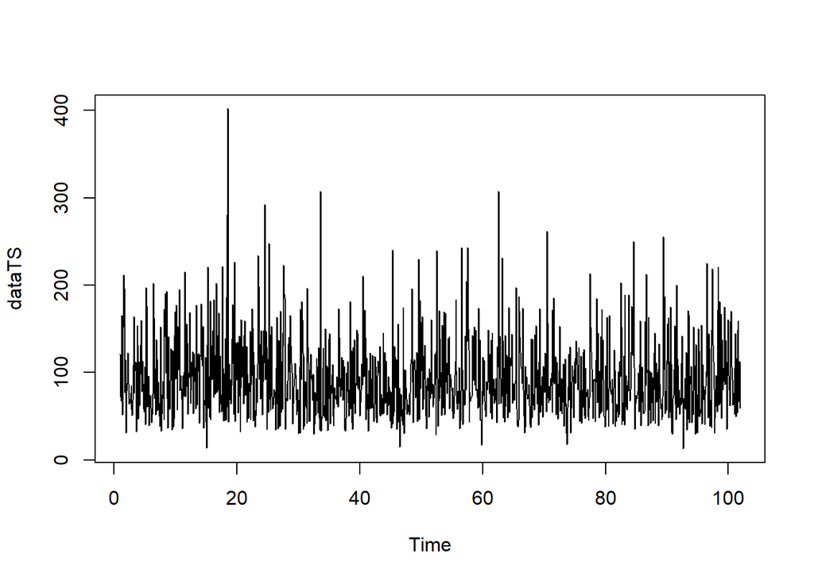

```r
plot.ts(dataTS)
```

# Периодограмма.

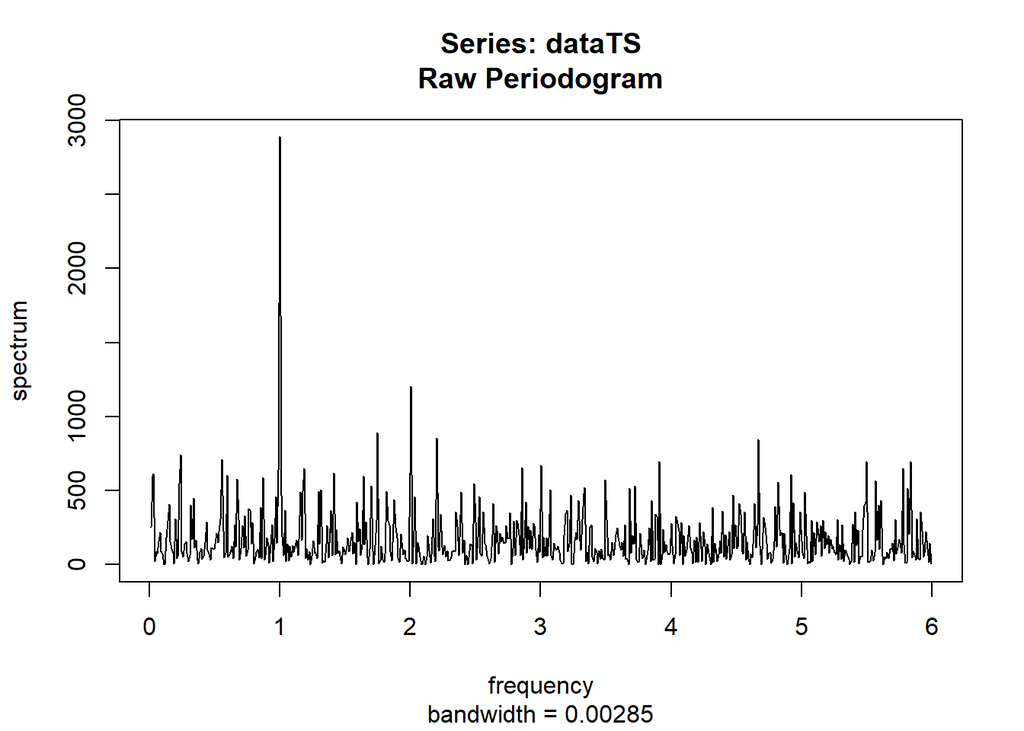

```r
SpecPGram <- spec.pgram(dataTS, detrend="True",  log = "no",  plot = TRUE)
```

тут по оси X: 0/12, 1/12, 2/12 и т.д. Получили, что скорее всего период нашего ряда = 12, что довольно логично. и много шума здесь.

# Автокорреляции

from: http://r-statistics.co/Time-Series-Analysis-With-R.html

Обычно используется для определения того, является ли временной ряд стационарным или нет. У стационарного временного ряда автокорреляция довольно быстро падает до нуля, но для нестационарного ряда она постепенно падает.

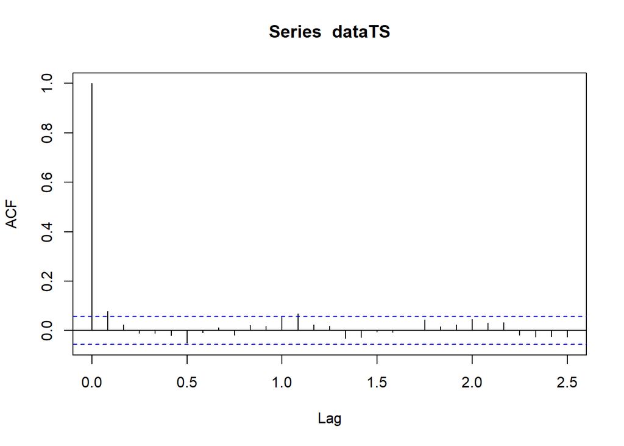

```r
acfRes <- acf(dataTS)
```

У нас получается, что тренда нет.

# Белый и красный шум:

## Периодограмма белого шума:

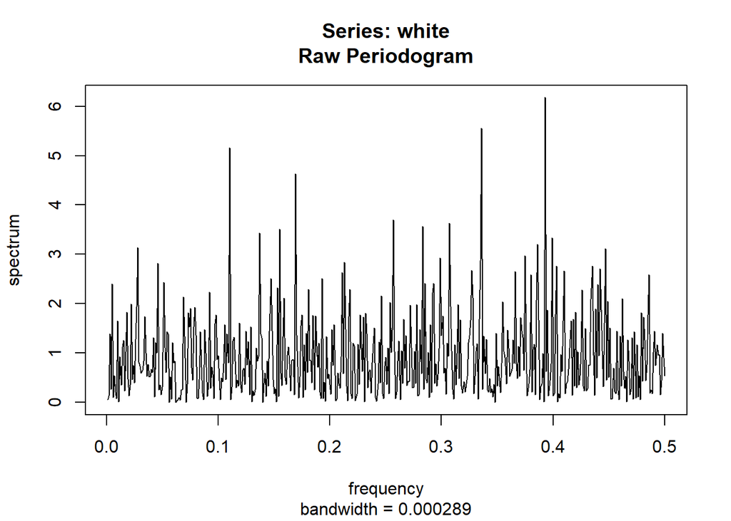

```r
white <- rnorm(1000)
spec.pgram(white,  log = "no",  plot = TRUE)
```

Сглаженная периодограмма:

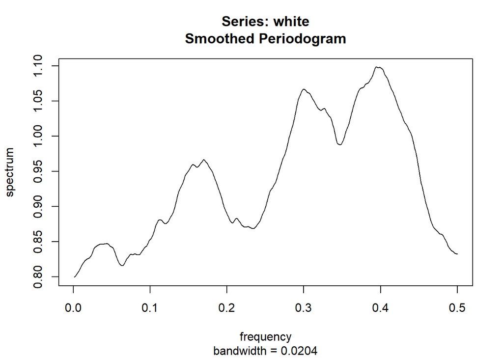

```r
spec.pgram(white, spans = c(50,50),  log = "no")
```

нанесем также две периодограммы на один график для наглядности:

Черным - периодограмма шума, красным — сглаженная периодограмма

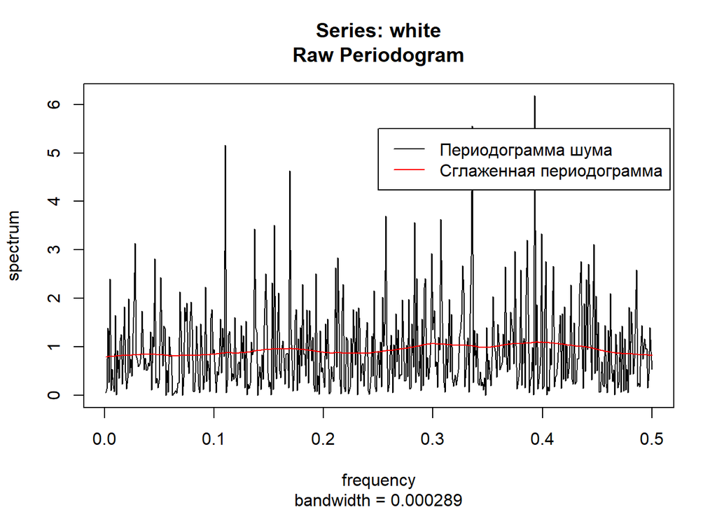

```r
spec.pgram(white,  log = "no",  plot = TRUE)
spec.pgram(white, spans = c(50,50),  log = "no",col="red", add=TRUE)
legend(0.25,5.5,c("Периодограмма шума", "Сглаженная периодограмма"), col=c("black", "red"),lty=c(1,1))
```

Смотрим на качество сглаживания как на качество выделения тренда, и здесь при ширине окна 50, получили гладкий, медленно меняющийся результат.

## Периодограмма красного шума:

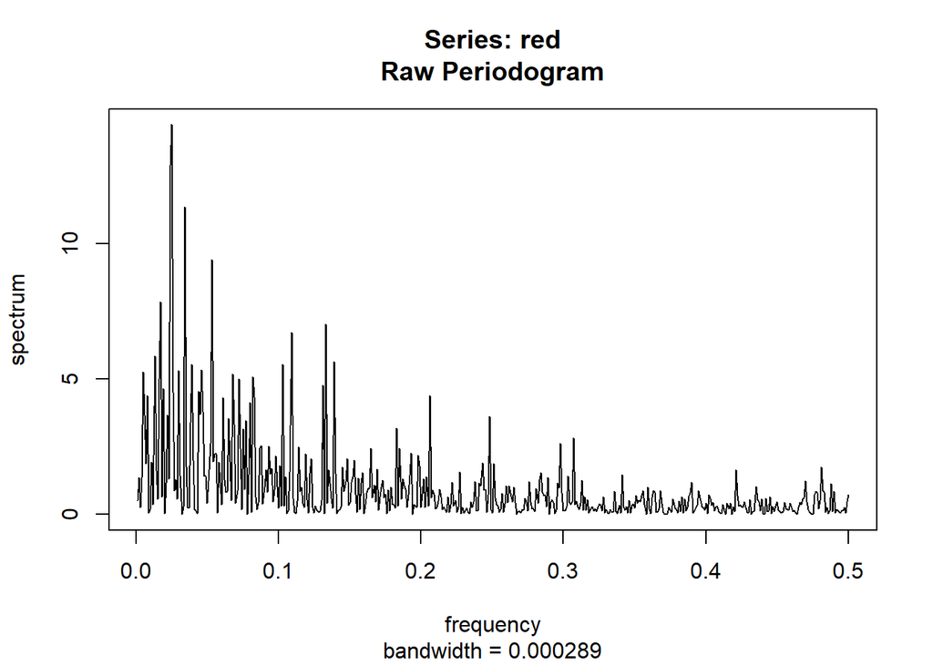

```r
red <- colored_noise(1000, 0, 1, 0.5)
spec.pgram(red,  log = "no",  plot = TRUE)
```

Сглаженная периодограмма:

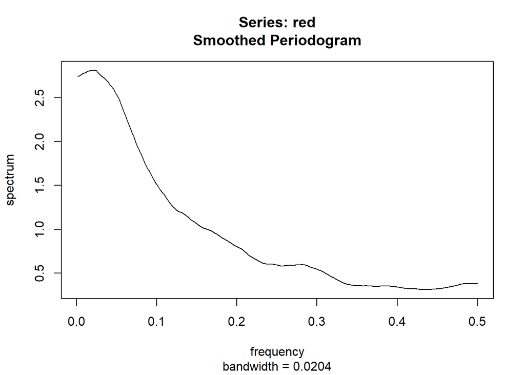

```r
spec.pgram(red, spans = c(50,50),  log = "no",  plot = TRUE)
```

нанесем также две периодограммы на один график для наглядности:

Черным - периодограмма шума, красным — сглаженная периодограмма

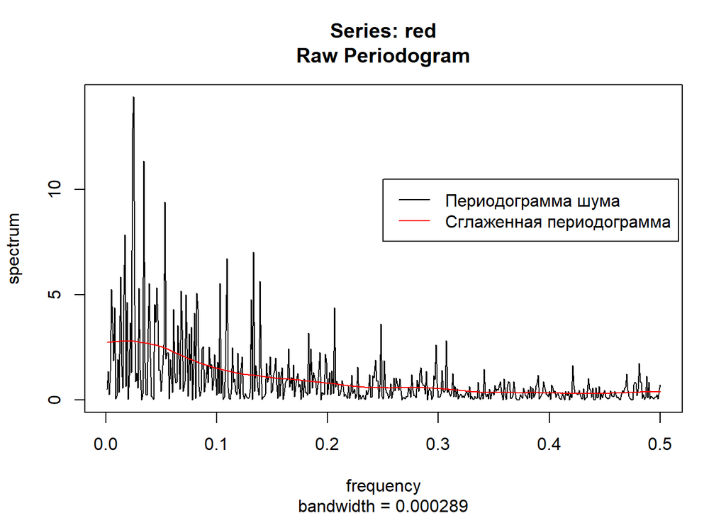

```r
spec.pgram(red,  log = "no",  plot = TRUE)
spec.pgram(red, spans = c(50,50),  log = "no",col="red", add=TRUE)
legend(0.25,10.5,c("Периодограмма шума", "Сглаженная периодограмма"), col=c("black", "red"),lty=c(1,1))
```

Смотрим на качество сглаживания как на качество выделения тренда, и здесь при ширине окна 50, получили гладкий, медленно меняющийся результат.

# Растекание частоты в периодограмме. Подправка длины ряда для ее устранения.

Было на паре: Пример:

$x_n=Acos(2\pi wn+\psi)$, $n=1,...,N$

а) $w=\frac{k}{N}$ => попадаем в решетку б) $w\neq\frac{k}{N}$ => cos не ортогонален ни одному вектору из базиса.

Промоделируем такой пример: (cos с частотой 2/7 и длина ряда 20)

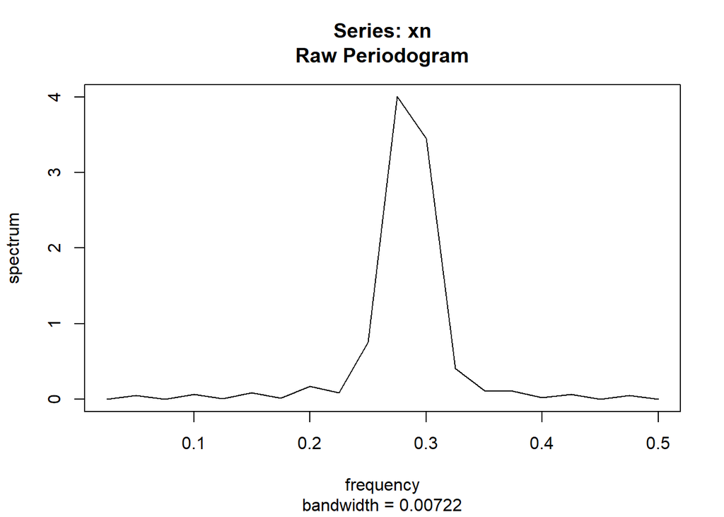

```r
xn <- cos(2*pi*(2/7)*c(1:20))
spec.pgram(xn, log = "no", detrend = FALSE, fast = FALSE, pad = TRUE, taper = 0)
```

Что делать в таком случае? 2 варианта: 1) ряд урезается 2) дополняется нулями

Добавим в ряд 1 ноль: (так как нам надо, чтоб $\frac{2N}{7}$ нацело)

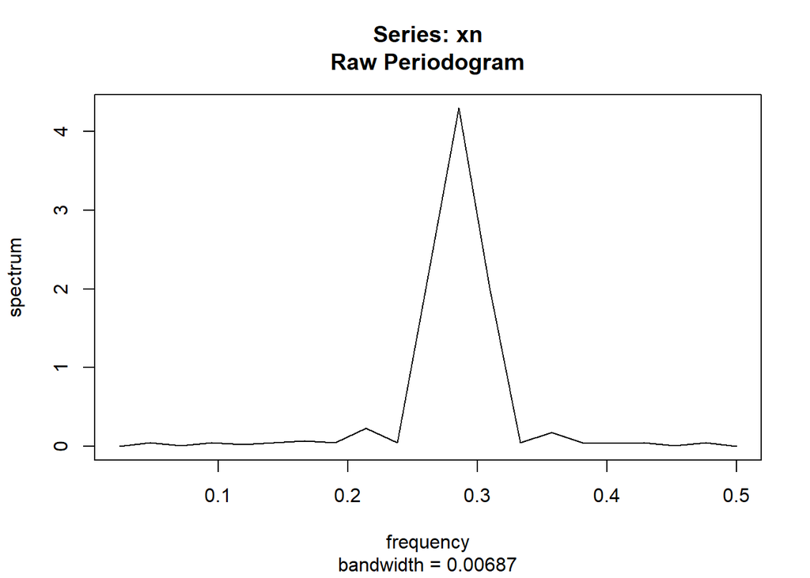

```r
xn <- c(xn, 0)
spec.pgram(xn, log = "no", detrend = FALSE, fast = FALSE, pad = TRUE, taper = 0)
```

# Выделение тренда у ряда с сезонностью (выбор длины окна в скользящем среднем).

Для выделения тренда у ряда с сезонностью с помощью скользящего среднего нужно взять окно кратное периоду. (равное или кратное, чем больше окно, тем более гладкий результат)

Функция скользящего среднего: ma()

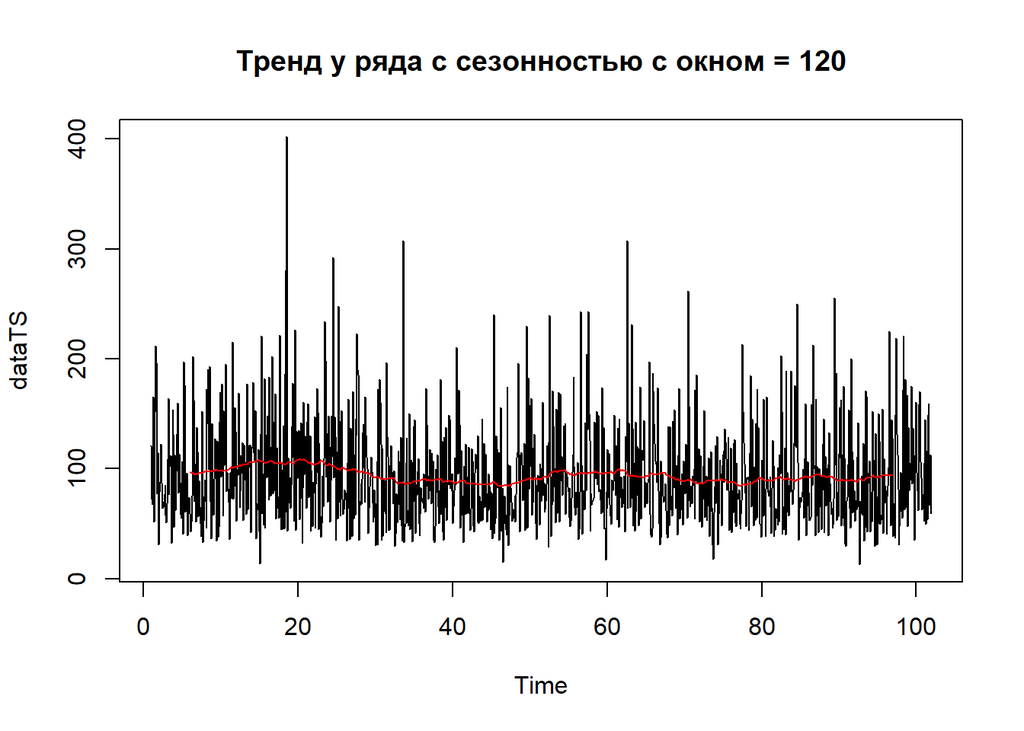

```r
plot(dataTS, main = "Тренд у ряда с сезонностью с окном = 120")
ma120 <- ma(dataTS, 120)
lines(ma120, col = "red")
```

Здесь концы не покрыты, далее (в пункте “фильтр скользящего среднего”) будет использоваться другая функция, которая покроет концы.

Для сравнения посмотрим на дургие варианты ширины окна:

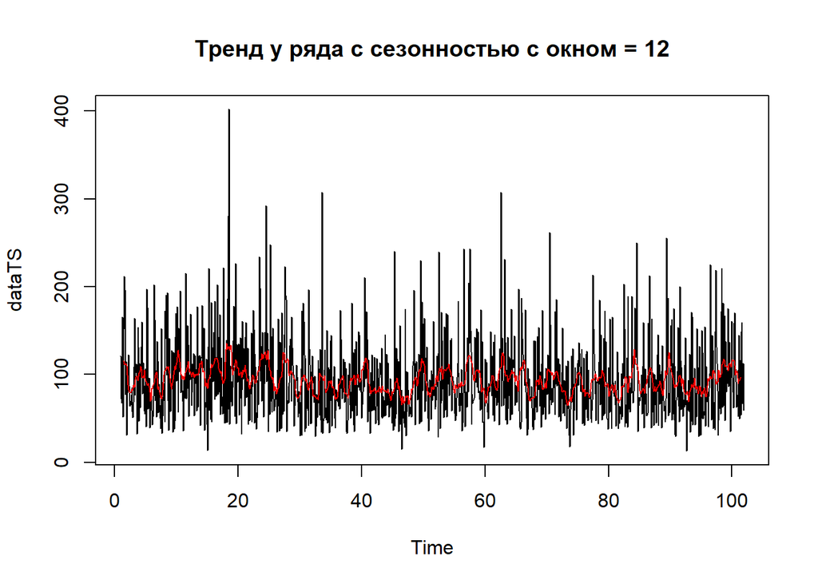

```r
plot(dataTS, main = "Тренд у ряда с сезонностью с окном = 12")
ma12 <- ma(dataTS, 12)
lines(ma12, col = "red")
```

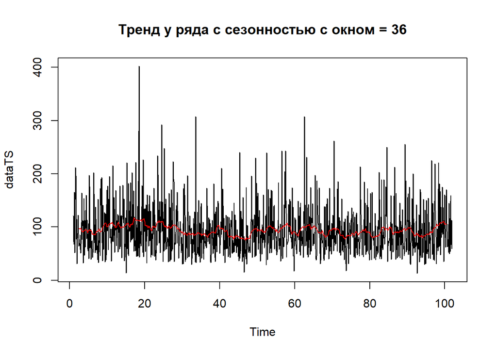

```r
plot(dataTS, main = "Тренд у ряда с сезонностью с окном = 36")
ma36 <- ma(dataTS, 36)
lines(ma36, col = "red")
```

Вывод: чем больше длина окна, тем более гладкий результат мы получаем.

# Периодограмма остатка после выделения тренда

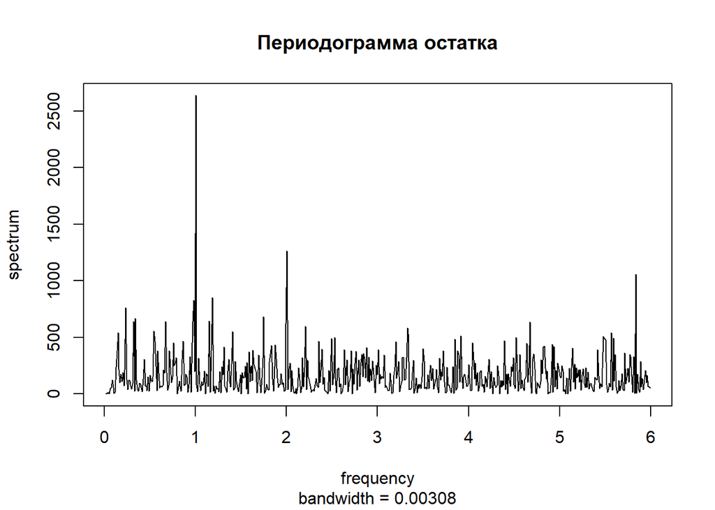

```r
OST <- dataTS-na.omit(ma120)
spec.pgram(OST, log="no",detrend="True", main="Периодограмма остатка",  plot = TRUE)
```

Здесь у нас частота 12 практически не снялась.

Посмотрим периодограмму остатка при ширине окна 240:

[figure not shown]

```r
plot(dataTS, main = "Тренд у ряда с сезонностью с окном = 120")
ma240 <- rollapply(dataTS, width=240, FUN=mean)
lines(ma240, col = "red")
```

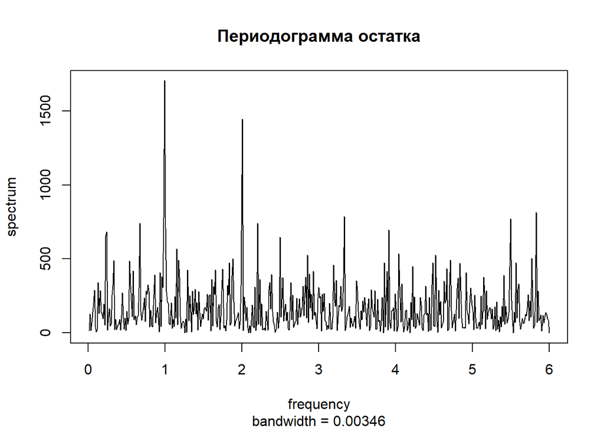

```r
OST <- dataTS-ma240
spec.pgram(OST, log="no",detrend="True", main="Периодограмма остатка",  plot = TRUE)
```

Здесь видно, что частота 12 уже гораздо сильнее снялась.

# Фильтр скользящего среднего:

Здесь му будем снова использовать скользящее среднее, но уже с другой функцией, чтобы “покрыть хвосты”

Пользуюсь встроенной функцией filter:

### Использование:

filter(x, filter, method = c(“convolution”, “recursive”), sides = 2, circular = FALSE, init)

### Аргументы:

x — одномерный или многомерный временной ряд.

filter — вектор коэффициентов фильтра в обратном порядке времени.

method — Либо “свертка” или “рекурсивный” (и может быть сокращено). Если для «свертки» используется скользящее среднее, то для «рекурсивной» используется авторегрессия.

sides — только для фильтров свертки. Если сторон = 1, коэффициенты фильтра только для прошлых значений; если стороны = 2, они центрированы вокруг запаздывания 0. В этом случае длина фильтра должна быть нечетной, но если она четная, больше фильтра направлено вперед, чем назад.

circular — только для фильтров свертки. Если TRUE, оберните фильтр вокруг концов ряда, в противном случае предположите, что внешние значения отсутствуют (NA).

init — только для рекурсивных фильтров. Задает начальные значения временного ряда непосредственно перед начальным значением в обратном порядке времени. По умолчанию это набор нулей.

## Зависимость результата от длины окна.

У меня поставлено CIRCULAR=TRUE, т.е. мы обрабытываем вместе с концами. Длина нашего ряда (1212) кратна периоду, так что мы можем использовать данную функцию.

У нашего ряда период 12. Рассмотрим окна с шириной 12, 120, 240.

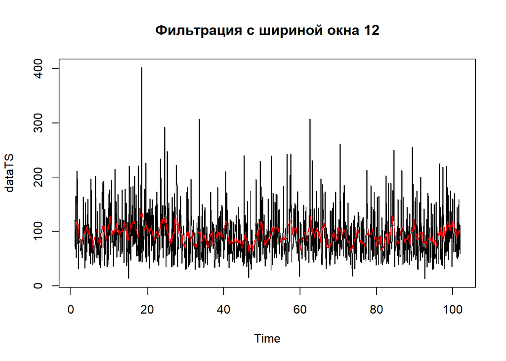

```r
filt1 <- stats::filter(dataTS, rep(1/12,12), method="convolution", sides=2, circular=TRUE)
plot(dataTS, type="l", col="black", main = "Фильтрация с шириной окна 12")
lines(filt1, col="red")
```

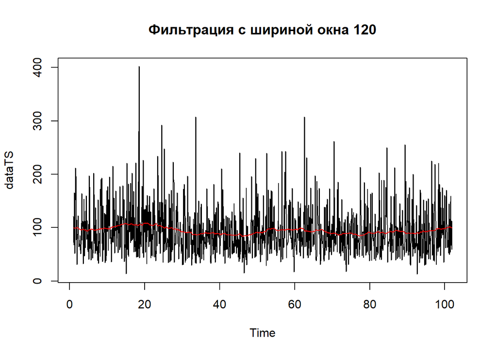

```r
filt1 <- stats::filter(dataTS, rep(1/120,120), method="convolution", sides=2, circular=TRUE)
plot(dataTS, type="l", col="black", main = "Фильтрация с шириной окна 120")
lines(filt1, col="red")
```

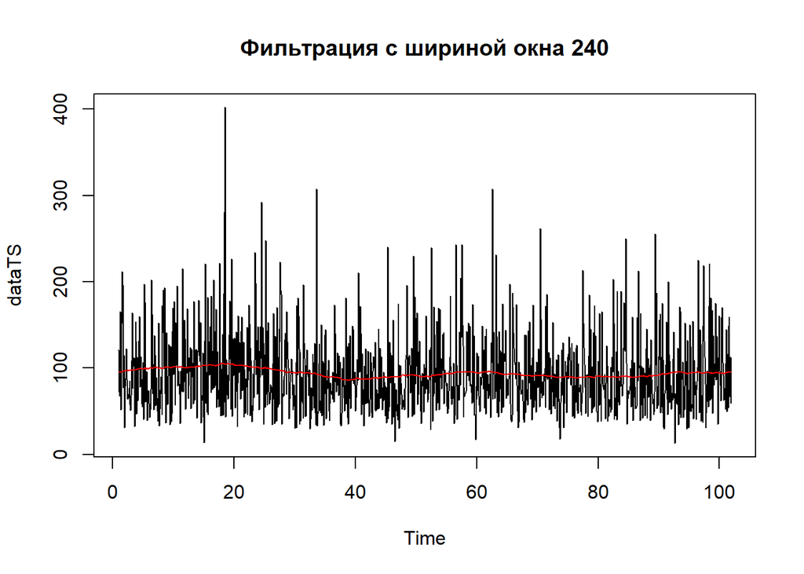

```r
filt1 <- stats::filter(dataTS, rep(1/240,240), method="convolution", sides=2, circular=TRUE)
plot(dataTS, type="l", col="black", main = "Фильтрация с шириной окна 240")
lines(filt1, col="red")
```

У нас “хвосты” покрыты.

Вопрос: как отработал фильтр в зависимости от ширины окна?

При выборе бОльшей ширина окна мы получали бОльшую гладкость.

# Смотрим на АЧХ фильтров:

Амплитудно-частотная характеристика (АЧХ) — зависимость амплитуды выходного сигнала некоторой системы от частоты её входного гармонического сигнала. Иногда эту характеристику называют «частотным откликом системы» (frequency response).

$A_\text{ф}(w)=|H_\text{ф}(e^{i2\pi w})|$ , где $H_\text{ф}(z)=\sum_ih_iz^{-i}$ — передаточная функция

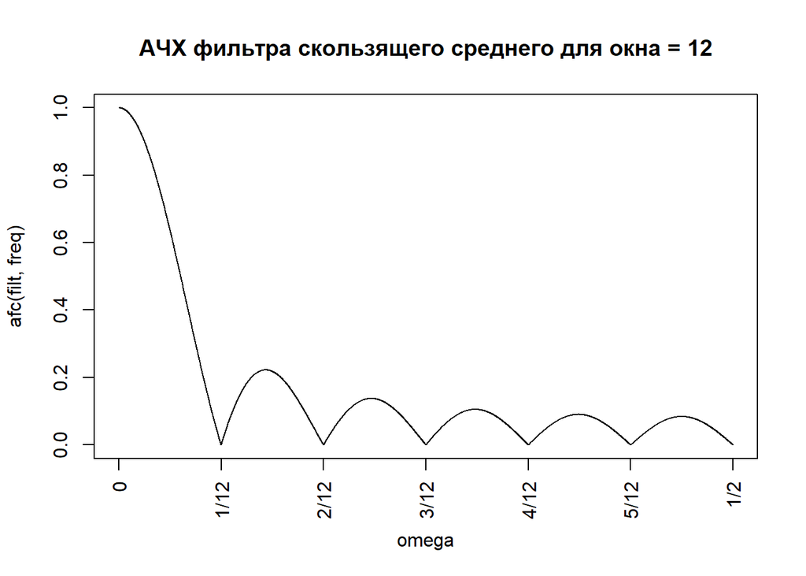

```r
afc <- function(filter, omega) {
    k <- seq_along(filter) - 1
    h <- function(o) sum(rev(filter) * exp(-k*1i * o))
    abs(sapply(omega, h))
}

freq <- seq(0, pi, 0.001)
filt <- rep(1/12, 12)
omega <- freq/2/pi
plot(afc(filt, freq) ~ omega, type = "l", xaxt="n", main = "АЧХ фильтра скользящего среднего для окна = 12")
axis(1, at = c( 0, 1/12, 2/12, 3/12, 4/12, 5/12, 1/2), labels = c("0","1/12", "2/12", "3/12", "4/12", "5/12","1/2"), las = 2)
```

Частоты 1/12, 2/12, 3/12 и т.д. этот фильтр превращает в 0. Он не сильно снимает высокие частоты.

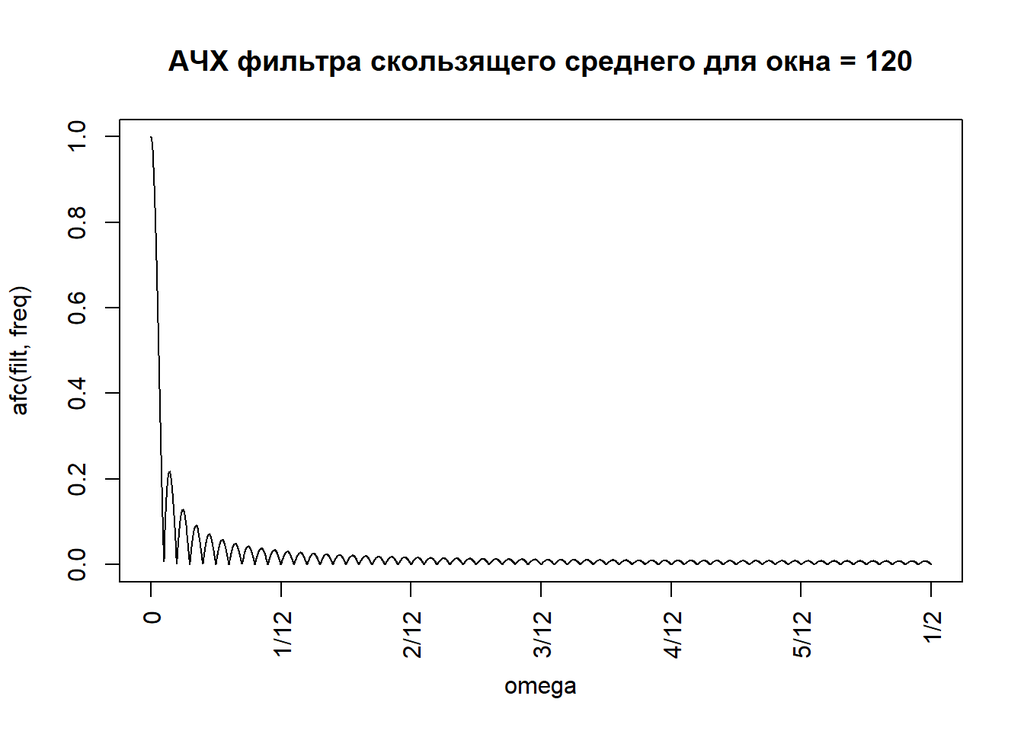

```r
freq <- seq(0, pi, 0.001)
filt <- rep(1/120, 120)
omega <- freq/2/pi
plot(afc(filt, freq) ~ omega, type = "l", xaxt="n", main = "АЧХ фильтра скользящего среднего для окна = 120")
axis(1, at = c( 0, 1/12, 2/12, 3/12, 4/12, 5/12, 1/2), labels = c("0","1/12", "2/12", "3/12", "4/12", "5/12","1/2"), las = 2)
```

[figure not shown]

```r
freq <- seq(0, pi, 0.001)
filt <- rep(1/240, 240)
omega <- freq/2/pi
plot(afc(filt, freq) ~ omega, type = "l", xaxt="n", main = "АЧХ фильтра скользящего среднего для окна = 120")
axis(1, at = c( 0, 1/12, 2/12, 3/12, 4/12, 5/12, 1/2), labels = c("0","1/12", "2/12", "3/12", "4/12", "5/12","1/2"), las = 2)
```

Т.е. при увеличении ширины окна фильтр начинает сильнее снимать высокие частоты.

# Аддитивная и мультипликативная модель

По нашему ряду на самом деле очень сложно понять, даже нельзя понять, аддитивная или мультипликативная модель.

Почему?

В мультипликативной модели размер колебаний (даже не только шум, а шум+периодичность) зависит от величины тренда.

В аддитивной модели значение тренда не имеет значения, колебания всегда примерно одинаковые.

Для того, чтобы понять, что модель мультипликативная, нам нужно, чтобы у тренда были разные значения. То есть чтобы он где-то был больше, где-то меньше. Тогда мы сможем увидеть, что в тех местах, где тренд больше, больше и колебания. Но в нашем случае тренд почти что константа (+-) и значение тренда всегда почти одинаковое. Поэтому нам не отчего оттолкнуться.

# Фильтр скользящей медианы.

Что тут хорошо? — робастная оценка

Встроенная функция: runmed

## Использование:

runmed(x, k, endrule = c(“median”,“keep”,“constant”), algorithm=NULL, print.level=0)

## Аргументы:

x — числовой вектор, «зависимая» переменная для сглаживания.

k — целочисленная ширина медианного окна; должно быть странно Turlach имел значение по умолчанию k <- 1 + 2 * мин ((n-1)% /% 2, потолок (0,1 * n)). Используйте k = 3 для «минимального» надежного сглаживания, устраняя изолированные выбросы.

endrule — символьная строка, указывающая, как должны обрабатываться значения в начале и конце (данных). Может быть сокращено. Возможные значения: “keep” — сохраняет первое и последнее значения k2 на обоих концах, где k2 - это половина полосы пропускания k2 = k% /% 2, т. е. y [j] = x [j] для j = 1,…, k2 и (n-k2 +1),…, n; “constant” — копирует медиану (y [1: k2]) в первые значения и аналогично для последних, делая сглаженные концы постоянными; “median” — по умолчанию сглаживает концы, используя симметричные медианы впоследствии меньшей пропускной способности, но для самого первого и последнего значения, где применяется надежное правило конечной точки. (т.е. для хвостов медиана будет с меньшим окном , но первое и последнее значения останутся теми, что и есть)

algorithm — символьная строка (частично совпадающая с «Turlach» или «Stuetzle») или значение по умолчанию NULL, указывающее, какой алгоритм должен применяться. Выбор по умолчанию зависит от n = length (x) и k, где «Turlach» будет использоваться для более крупных задач.

print.level — целое число, указывающее на многословность алгоритма; должны редко меняться средними пользователями.

## Применение скользящей медианы:

Возьмем ширину окна: 120 Способ обрабатывания концов : median

Но нам необходимо брать ширину окна нечетной, чтоб точно определить середину. Поэтому, ширина окна 121:

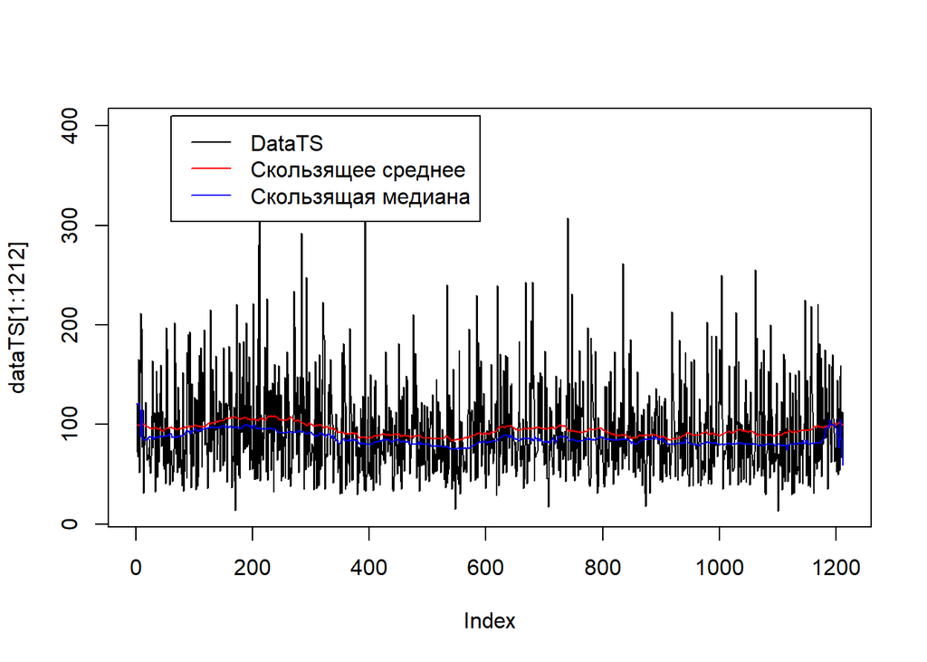

```r
runmed121 <- stats::runmed(dataTS, 121, endrule="median")
filt1 <- stats::filter(dataTS, rep(1/120,120), method="convolution", sides=2, circular=TRUE)

plot(dataTS[1:1212],col="black",type="l")
lines(filt1[1:1212] ,col="red")
lines((runmed121[1:1212]),col="blue")
legend(60,410,c("DataTS", "Скользящее среднее","Скользящая медиана"), col=c("black","red","blue"),lty=c(1,1))
```

Как и говорилось на паре про мои данные, скользящая медиана лежит немного ниже скользящего среднего. (хотя есть и не такие участки)

# Фильтр Hodrik-Prescott

$min_{\{s_i\}}(\sum_{i=1}^N(x_i-s_i)^2+\lambda\sum_{i=2}^{N-1}((s_{i+1}-s_i)-(s_i-s_{i-1}))^2)$

1е слагаемое: квадраты отклонений от исходного ряда

2е слагаемое: вторая производная, мы ее заменяем разностью разностей.

Рекомендовано использовать $\lambda=129600$. Вообще этот параметр отвечает за гладкость функции.

Встроенная функция: hpfilter

## Использование:

hpfilter(x,freq=NULL,type=c(“lambda”,“frequency”),drift=FALSE)

## Аргументы:

x — регулярный временной ряд.

type — символ, обозначающий тип фильтра: «лямбда», для фильтра, который использует параметр штрафа сглаживания фильтра Ходрика-Прескотта (по умолчанию). Эти типы связаны: $\lambda$ = (2*sin(pi/frequency))^{-4}.

freq — целое число, если type = “lambda”, то freq - это параметр сглаживания (lambda) фильтра Ходрика-Прескотта, если type = “Frequency”, то freq - частота среза фильтра Ходрика-Прескотта.

drift — логический, ЛОЖЬ, если нет дрейфа во временных рядах (по умолчанию), ИСТИНА, если дрейф во временных рядах.

## Применение фильтра Hodrik-Prescott:

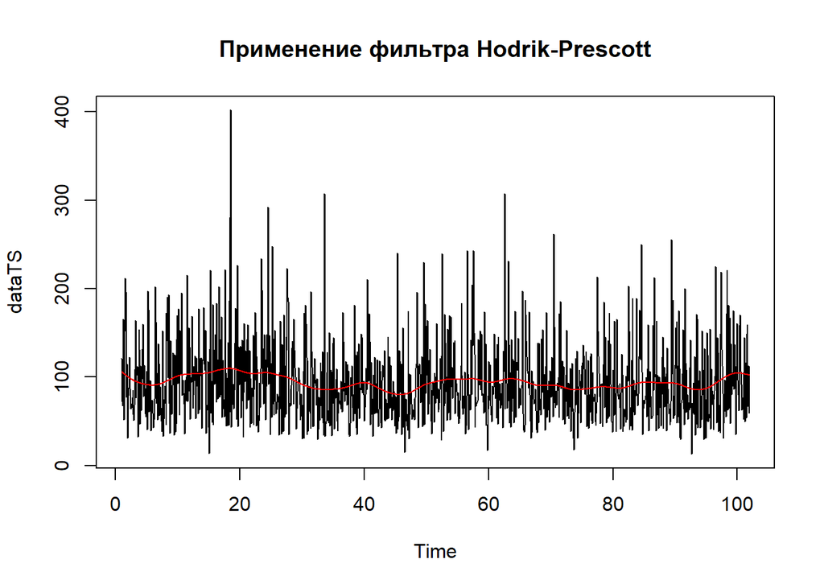

```r
DataHP1 <- hpfilter(dataTS, freq=129600, type="lambda")

plot(dataTS, main="Применение фильтра Hodrik-Prescott")
lines(DataHP1$trend, col="red")
```

Нанесем на график еще выделение тренда с помощью скользящего среднего с шириной окна 120 для того, чтобы сравнить гладкость результата:

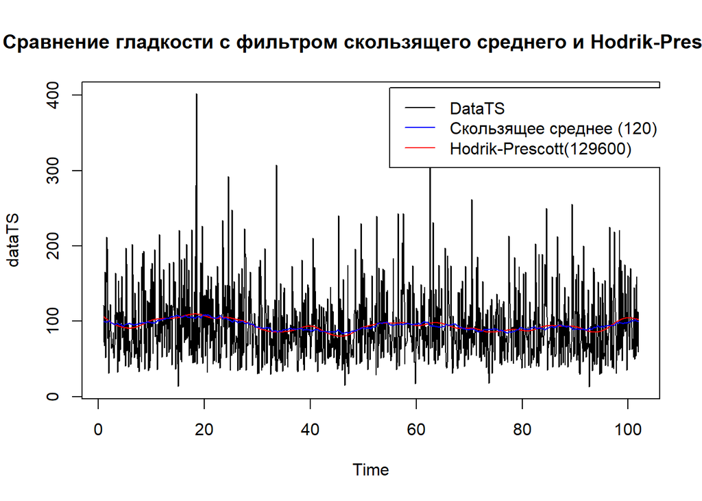

```r
plot(dataTS, main="Сравнение гладкости с фильтром скользящего среднего и Hodrik-Prescott")
lines(DataHP1$trend, col="red")
lines(filt1 ,col="blue")
legend(55,410,c("DataTS", "Скользящее среднее (120)","Hodrik-Prescott(129600)"), col=c("black", "blue", "red"),lty=c(1,1))
```

Если параметр $\lambda$ отвечает за гладкость, что будет если взять его еще больше? например, 200000

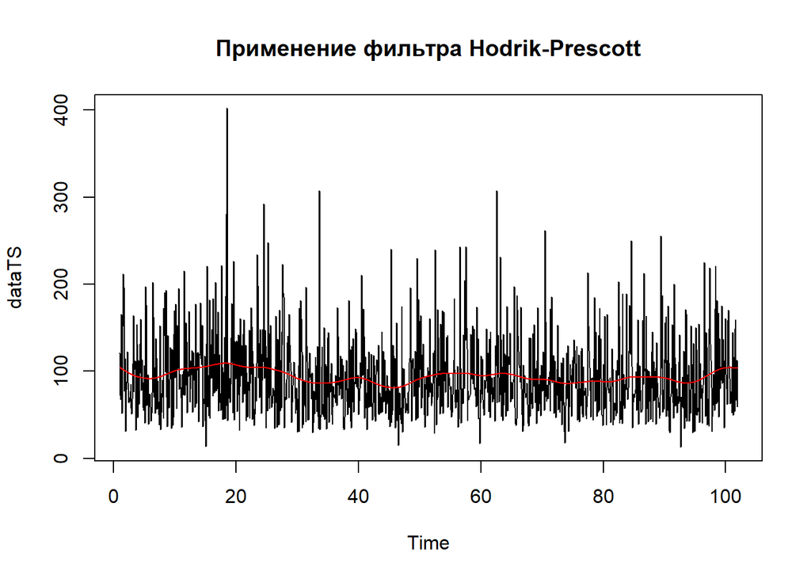

```r
DataHP2 <- hpfilter(dataTS, freq=200000, type="lambda")

plot(dataTS, main="Применение фильтра Hodrik-Prescott")
lines(DataHP2$trend, col="red")
```

Разница не большая. А если взять маленькое $\lambda$ ?

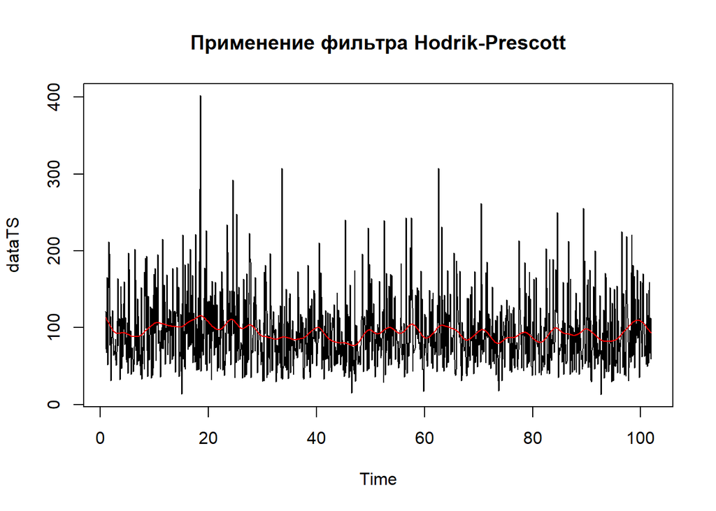

```r
DataHP3 <- hpfilter(dataTS, freq=10000, type="lambda")

plot(dataTS, main="Применение фильтра Hodrik-Prescott")
lines(DataHP3$trend, col="red")
```

Здесь уже довольно хорошо видно, что вторая производная стала больше, отчего более сильные изменения получились.

# Полиномиальная регрессия

## Линейная регрессия

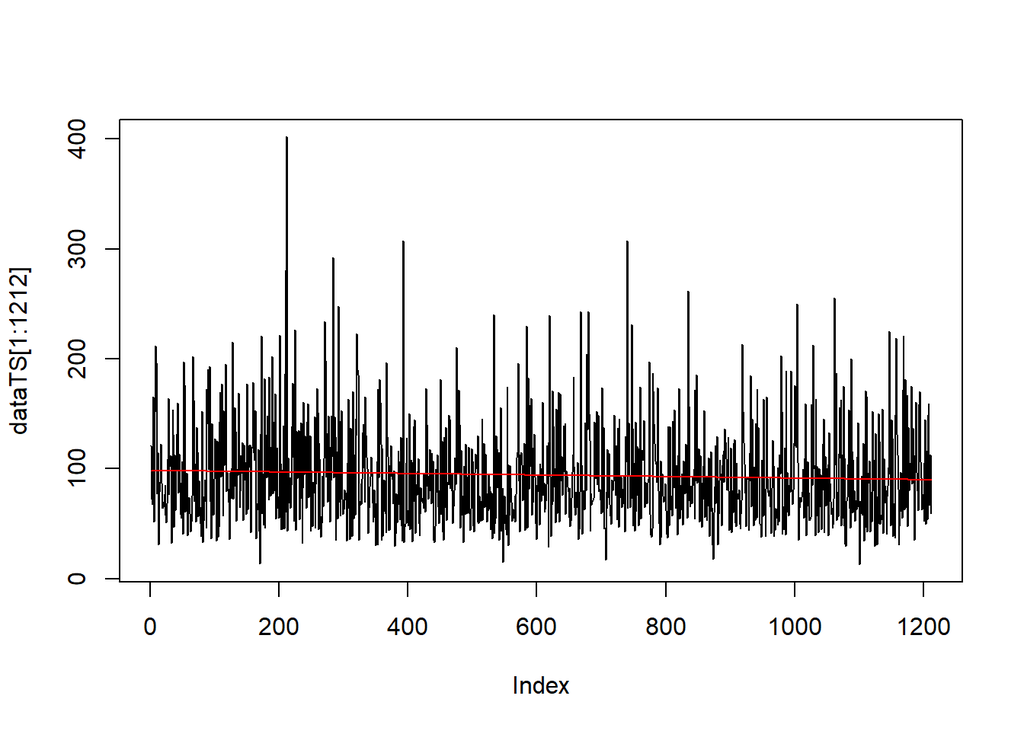

```r
lm1 <- lm(dataTS ~ c(1:1212))

plot(dataTS[1:1212], type="l")
lines(lm1$fitted.values[1:1212], col = "red")
```

## Полиномиальная регрессия

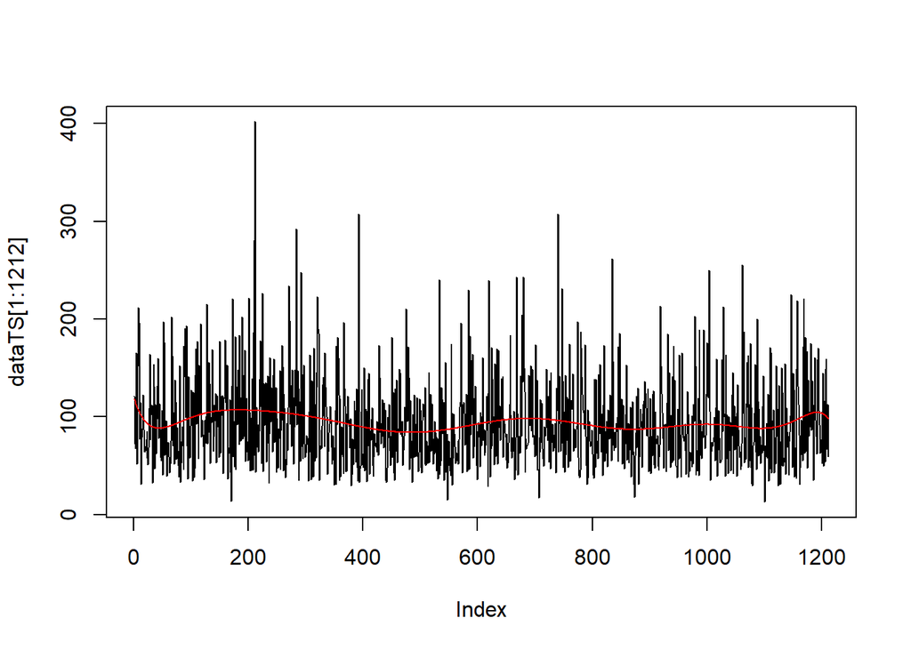

```r
model3 <- lm(dataTS ~ poly(c(1:1212),11))

plot(dataTS[1:1212], type="l")
lines(model3$fitted.values[1:1212], col = "red")
```

Вообще, пробовалось брать разные степени полиномов, уже после 11 особо ничего не меняется. Т.е. скорее всего у нас тут все пытается выделить более-менее константный тренд

# LOESS (локальная регрессия)

Встроенная функция: loess

## Использование:

loess(formula, data, weights, subset, na.action, model = FALSE, span = 0.75, enp.target, degree = 2, parametric = FALSE, drop.square = FALSE, normalize = TRUE, family = c(“gaussian”, “symmetric”), method = c(“loess”, “model.frame”), control = loess.control(…), …)

## Аргументы:

formula — формула, указывающая числовой ответ и от одного до четырех числовых предикторов (лучше всего указывать через взаимодействие, но также можно указывать дополнительно). При необходимости будет приведен к формуле.

data — необязательный фрейм данных, список или окружение (или объект, приводимый as.data.frame в фрейм данных), содержащий переменные в модели. Если данные не найдены, переменные берутся из среды (формулы), обычно из среды, из которой вызывается лесс.

weights — дополнительные веса для каждого случая.

subset — необязательная спецификация подмножества данных, которые будут использоваться.

na.action — действие с отсутствующими значениями в ответе или предикторах. По умолчанию используется getOption (“na.action”).

model — должен ли быть возвращен фрейм модели?

enp.target — альтернативный способ указать диапазон, как примерное эквивалентное количество используемых параметров.

degree — степень используемых многочленов, обычно 1 или 2. (Степень 0 также допускается, но см. «Примечание».)

parametric — должны ли какие-либо термины соответствовать глобально, а не локально? Термины могут быть указаны по имени, номеру или в виде логического вектора той же длины, что и число предикторов.

drop.square — для совпадений с более чем одним предиктором и степенью = 2 следует ли отбрасывать квадратный член для определенных предикторов? Условия указаны так же, как и для параметрических.

normalize — следует ли нормализовать предикторы к общей шкале, если их больше одного? Нормализация используется для установки стандартного отклонения с усечением 10% на единицу. Установите значение false для пространственных координатных предикторов и других, о которых известно, что они находятся в общем масштабе.

family — если «гауссовская» аппроксимация выполняется методом наименьших квадратов, а если «симметричная», то с би-весовой функцией Тьюки используется повторно нисходящая оценка М. Может быть сокращено.

method — установить модель или просто извлечь рамку модели. Может быть сокращено.

control — параметры управления: см. loess.control.

… — параметры управления также могут быть предоставлены напрямую (если управление не указано).

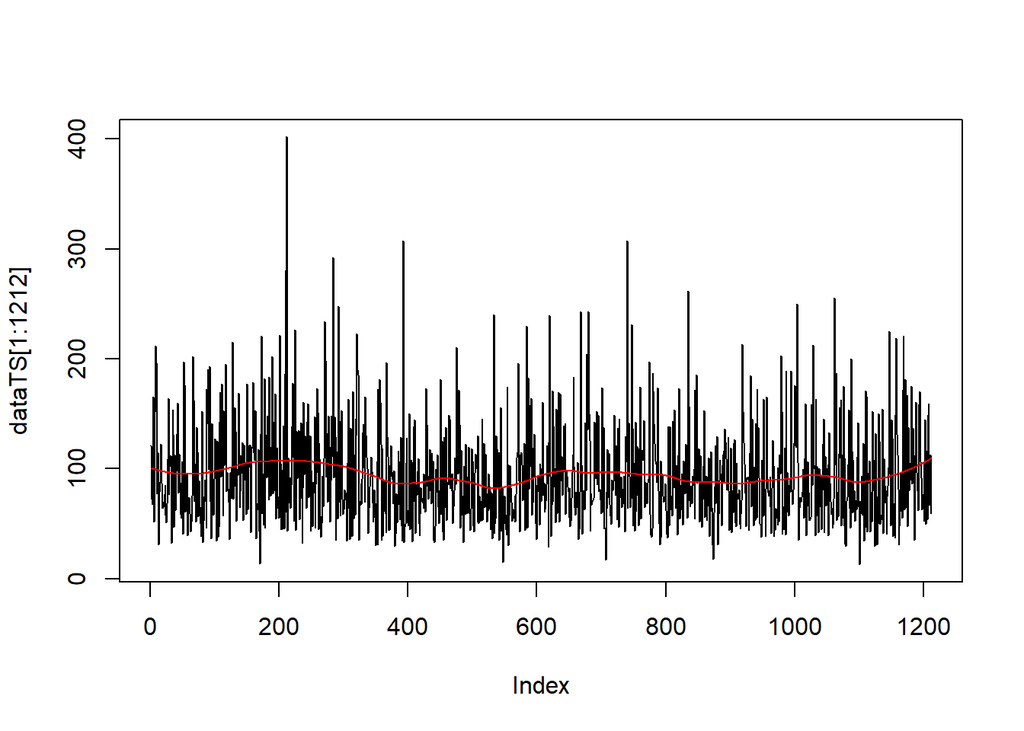

```r
dataLOESS <- loess(dataTS ~ c(1:1212), data = dataTS, span=0.2)

plot(dataTS[1:1212], type="l")
lines(predict(dataLOESS)[1:1212], col = "red")
```

Сравним это выделение тренда с другими нанеся на один график:

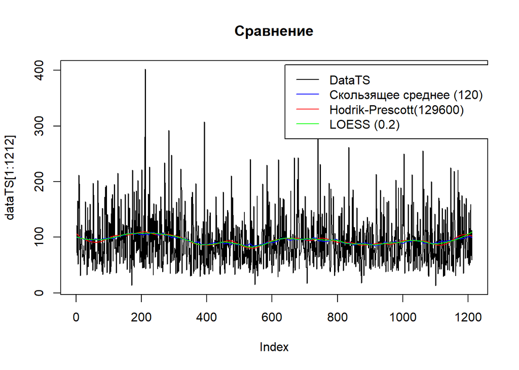

```r
plot(dataTS[1:1212], type="l", main="Сравнение")
lines(DataHP1$trend[1:1212], col="red")
lines(filt1[1:1212] ,col="blue")
lines(predict(dataLOESS)[1:1212], col = "green")
legend(640,410,c("DataTS", "Скользящее среднее (120)","Hodrik-Prescott(129600)", "LOESS (0.2)"), col=c("black", "blue", "red", "green"),lty=c(1,1))
```